# Report_Project1

R. Ruiz-Cruz

12/08/2016

## 1.- Load the data

The data for the analysis is included in the archive “activity.csv”. This archive is loaded and stored in the variable *data*.

```r
data <- read.csv("activity.csv",sep=",")
head(data)
```

```
##   steps       date interval
## 1    NA 2012-10-01        0
## 2    NA 2012-10-01        5
## 3    NA 2012-10-01       10
## 4    NA 2012-10-01       15
## 5    NA 2012-10-01       20
## 6    NA 2012-10-01       25
```

The data have three columns named *steps*, *date*, *interval*.

## 2.- Histogram of the total number of steps taken each day

The total number of steps taken each day is calculated and it is show in a histogram.

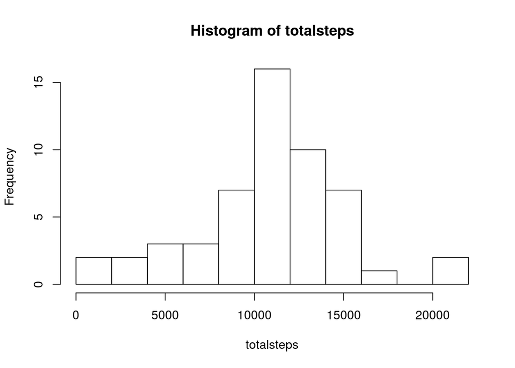

```r
totalsteps <- with(data,tapply(steps,date,sum))
hist(totalsteps,breaks = 15)
```

The basic statistical information can be obtained by the command ‘summary’.

```r
summary(data)
```

```
##      steps                date          interval
##  Min.   :  0.00   2012-10-01:  288   Min.   :   0.0
##  1st Qu.:  0.00   2012-10-02:  288   1st Qu.: 588.8
##  Median :  0.00   2012-10-03:  288   Median :1177.5
##  Mean   : 37.38   2012-10-04:  288   Mean   :1177.5
##  3rd Qu.: 12.00   2012-10-05:  288   3rd Qu.:1766.2
##  Max.   :806.00   2012-10-06:  288   Max.   :2355.0
##  NA's   :2304     (Other)   :15840
```

## 3.- Mean and median number of steps taken each day

The information presented above is calculated considering the all the data. The mean and median of the steps taken each day can be give us an extra information.

```r
mean_day <- with(data,tapply(steps,date,mean))
median_day <- with(data,tapply(steps,date,median))
mean_day
```

```
## 2012-10-01 2012-10-02 2012-10-03 2012-10-04 2012-10-05 2012-10-06
##         NA  0.4375000 39.4166667 42.0694444 46.1597222 53.5416667
## 2012-10-07 2012-10-08 2012-10-09 2012-10-10 2012-10-11 2012-10-12
## 38.2465278         NA 44.4826389 34.3750000 35.7777778 60.3541667
## 2012-10-13 2012-10-14 2012-10-15 2012-10-16 2012-10-17 2012-10-18
## 43.1458333 52.4236111 35.2048611 52.3750000 46.7083333 34.9166667
## 2012-10-19 2012-10-20 2012-10-21 2012-10-22 2012-10-23 2012-10-24
## 41.0729167 36.0937500 30.6284722 46.7361111 30.9652778 29.0104167
## 2012-10-25 2012-10-26 2012-10-27 2012-10-28 2012-10-29 2012-10-30
##  8.6527778 23.5347222 35.1354167 39.7847222 17.4236111 34.0937500
## 2012-10-31 2012-11-01 2012-11-02 2012-11-03 2012-11-04 2012-11-05
## 53.5208333         NA 36.8055556 36.7048611         NA 36.2465278
## 2012-11-06 2012-11-07 2012-11-08 2012-11-09 2012-11-10 2012-11-11
## 28.9375000 44.7326389 11.1770833         NA         NA 43.7777778
## 2012-11-12 2012-11-13 2012-11-14 2012-11-15 2012-11-16 2012-11-17
## 37.3784722 25.4722222         NA  0.1423611 18.8923611 49.7881944
## 2012-11-18 2012-11-19 2012-11-20 2012-11-21 2012-11-22 2012-11-23
## 52.4652778 30.6979167 15.5277778 44.3993056 70.9270833 73.5902778
## 2012-11-24 2012-11-25 2012-11-26 2012-11-27 2012-11-28 2012-11-29
## 50.2708333 41.0902778 38.7569444 47.3819444 35.3576389 24.4687500
## 2012-11-30
##         NA
```

```r
median_day
```

```
## 2012-10-01 2012-10-02 2012-10-03 2012-10-04 2012-10-05 2012-10-06
##         NA          0          0          0          0          0
## 2012-10-07 2012-10-08 2012-10-09 2012-10-10 2012-10-11 2012-10-12
##          0         NA          0          0          0          0
## 2012-10-13 2012-10-14 2012-10-15 2012-10-16 2012-10-17 2012-10-18
##          0          0          0          0          0          0
## 2012-10-19 2012-10-20 2012-10-21 2012-10-22 2012-10-23 2012-10-24
##          0          0          0          0          0          0
## 2012-10-25 2012-10-26 2012-10-27 2012-10-28 2012-10-29 2012-10-30
##          0          0          0          0          0          0
## 2012-10-31 2012-11-01 2012-11-02 2012-11-03 2012-11-04 2012-11-05
##          0         NA          0          0         NA          0
## 2012-11-06 2012-11-07 2012-11-08 2012-11-09 2012-11-10 2012-11-11
##          0          0          0         NA         NA          0
## 2012-11-12 2012-11-13 2012-11-14 2012-11-15 2012-11-16 2012-11-17
##          0          0         NA          0          0          0
## 2012-11-18 2012-11-19 2012-11-20 2012-11-21 2012-11-22 2012-11-23
##          0          0          0          0          0          0
## 2012-11-24 2012-11-25 2012-11-26 2012-11-27 2012-11-28 2012-11-29
##          0          0          0          0          0          0
## 2012-11-30
##         NA
```

## 4.- Time series plot of the average number of steps taken

The average number of steps can be more friendly if the information is presented in a plot.

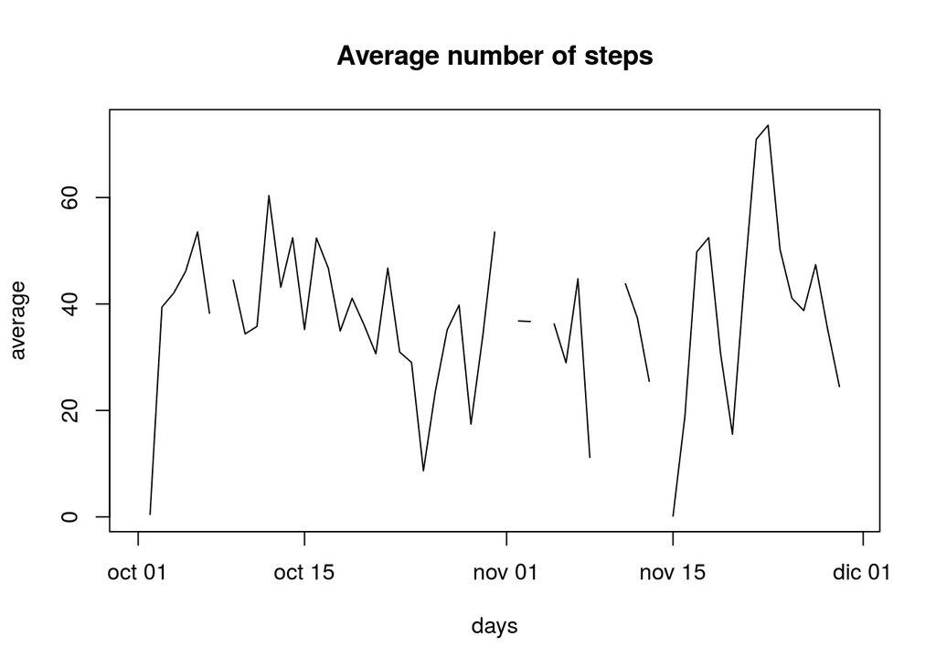

```r
fdates <- as.Date(unique(data$date))
plot(fdates,mean_day,type="l",main="Average number of steps",xlab = "days",ylab = "average")
```

The 5-minute interval with tje maximum number of steps is obtained as follows:

```r
ind <- which.max(data$steps);
data[ind,]
```

```
##       steps       date interval
## 16492   806 2012-11-27      615
```

In order discrad the missing data, we can obtain a subet of *data* considering only the information where the steps number is no “NA” (*!is.na(data$steps)*). The new data is stored in the variable *data0*.

```r
data0 <- subset(data,!is.na(data$steps))
data0$date <- as.Date(data0$date)
head(data0)
```

```
##     steps       date interval
## 289     0 2012-10-02        0
## 290     0 2012-10-02        5
## 291     0 2012-10-02       10
## 292     0 2012-10-02       15
## 293     0 2012-10-02       20
## 294     0 2012-10-02       25
```

Now, we can obtain again the total number of steps each day using the new variable *data0*.

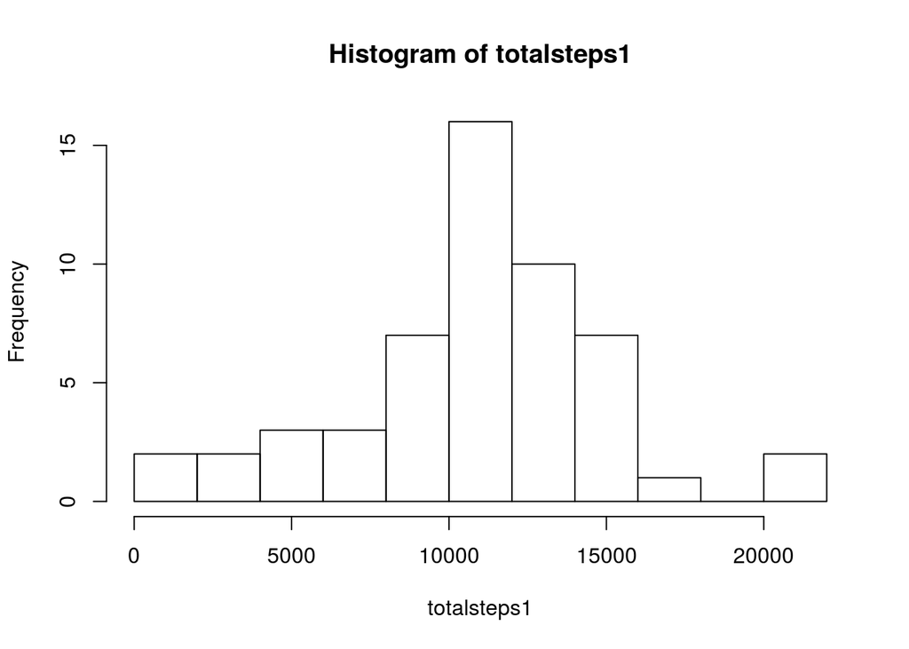

```r
totalsteps1 <- with(data0,tapply(steps,date,sum))
hist(totalsteps1,breaks=15)
```

## 8.- Comparison the average number of steps taken per 5-minute interval across weekdays and weekends

The steps average in the wekkends and the weekdays can be obtained as follows:

```r
m1 <- mean(data0$steps[!grepl("sáb|dom",weekdays(data0$date,abbreviate = TRUE))])
m2 <- mean(data0$steps[grepl("sáb|dom",weekdays(data0$date,abbreviate = TRUE))])
m1
```

```
## [1] 35.33796
```

```r
m2
```

```
## [1] 43.07837
```

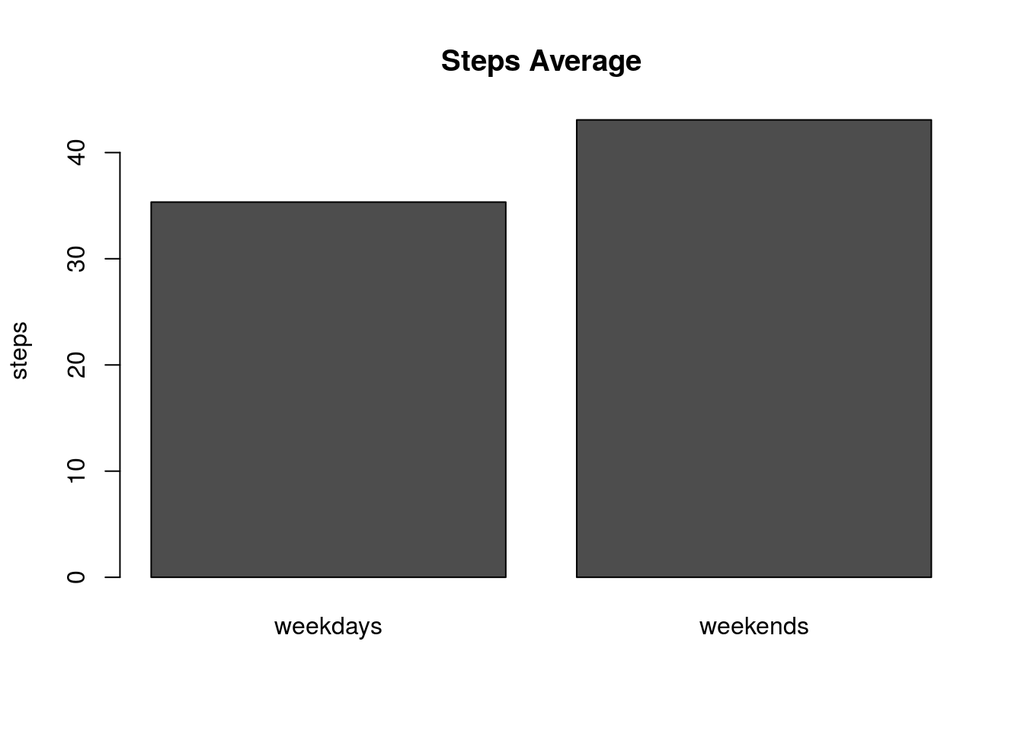

```r
barplot(height = cbind(weekdays = m1,weekends = m2),main = "Steps Average",ylab = "steps")
```